# ca4

## AI - CA4 - Machine learning - Mohammad Farrahi - 810198451

### Importing necessary modules and functions

```python
import pandas as pd
from sklearn import preprocessing
from sklearn.feature_selection import mutual_info_classif
from sklearn.feature_extraction.text import CountVectorizer
from sklearn.model_selection import train_test_split, GridSearchCV
from sklearn.tree import DecisionTreeClassifier
from sklearn.ensemble import RandomForestClassifier
from sklearn.metrics import accuracy_score, confusion_matrix, ConfusionMatrixDisplay, plot_confusion_matrix
import matplotlib.pyplot as plt
```

### Loading data

```python
df = pd.read_csv("dataset.csv")
```

### Phase 0 - 1

```python
df.describe()
```

|  | release_year |
| --- | --- |
| count | 11059.000000 |
| mean | 2014.209603 |
| std | 8.959517 |
| min | 1925.000000 |
| 25% | 2013.000000 |
| 50% | 2017.000000 |
| 75% | 2019.000000 |
| max | 2021.000000 |

As we can see, output of describe function, gives us some statistical info about numerical features of data, which here is only _release*year* feature

```python
df.info()
```

```
<class 'pandas.core.frame.DataFrame'>
RangeIndex: 11059 entries, 0 to 11058
Data columns (total 7 columns):
 #   Column        Non-Null Count  Dtype
---  ------        --------------  -----
 0   type          11059 non-null  object
 1   title         11059 non-null  object
 2   cast          9694 non-null   object
 3   country       8364 non-null   object
 4   release_year  11059 non-null  int64
 5   listed_in     11059 non-null  object
 6   description   11059 non-null  object
dtypes: int64(1), object(6)
memory usage: 604.9+ KB
```

This function gives some info about datatype of each feature and number of non-null values of each column

### Phase 0 - 2

```python
null_count = df.isna().sum()
(null_count / df.shape[0]) * 100
```

```
type             0.000000
title            0.000000
cast            12.342888
country         24.369292
release_year     0.000000
listed_in        0.000000
description      0.000000
dtype: float64
```

### Phase 1 - 1

```python
df = df.dropna(subset=['cast'])
df.fillna(df.mode().iloc[0], inplace=True)
df.info()
```

```
<class 'pandas.core.frame.DataFrame'>
Int64Index: 9694 entries, 1 to 11058
Data columns (total 7 columns):
 #   Column        Non-Null Count  Dtype
---  ------        --------------  -----
 0   type          9694 non-null   object
 1   title         9694 non-null   object
 2   cast          9694 non-null   object
 3   country       9694 non-null   object
 4   release_year  9694 non-null   int64
 5   listed_in     9694 non-null   object
 6   description   9694 non-null   object
dtypes: int64(1), object(6)
memory usage: 605.9+ KB
```

1 - dropping NaN vlues : in this method, we simply drop rows(samples) that there is a feature in it with NaN value. We use this method to handle NaN values in *cast* column. Because we can't fill this NaN values with any rational value.

### Phase 1 - 2

```python
min_max_scaler = preprocessing.MinMaxScaler()
norm_df = df.copy(deep=True)
norm_df['release_year'] = min_max_scaler.fit_transform(pd.DataFrame(df['release_year']))

norm_df
```

|  | type | title | cast | country | release_year | listed_in | description |
| --- | --- | --- | --- | --- | --- | --- | --- |
| 1 | TV Show | Blood & Water | Ama Qamata, Khosi Ngema, Gail Mabalane, Thaban... | South Africa | 1.000000 | International TV Shows, TV Dramas, TV Mysteries | After crossing paths at a party, a Cape Town t... |
| 2 | TV Show | Ganglands | Sami Bouajila, Tracy Gotoas, Samuel Jouy, Nabi... | United States | 1.000000 | Crime TV Shows, International TV Shows, TV Act... | To protect his family from a powerful drug lor... |
| 4 | TV Show | Kota Factory | Mayur More, Jitendra Kumar, Ranjan Raj, Alam K... | India | 1.000000 | International TV Shows, Romantic TV Shows, TV ... | In a city of coaching centers known to train I... |
| 5 | TV Show | Midnight Mass | Kate Siegel, Zach Gilford, Hamish Linklater, H... | United States | 1.000000 | TV Dramas, TV Horror, TV Mysteries | The arrival of a charismatic young priest brin... |
| 6 | Movie | My Little Pony: A New Generation | Vanessa Hudgens, Kimiko Glenn, James Marsden, ... | United States | 1.000000 | Children & Family Movies | Equestria's divided. But a bright-eyed hero be... |
| ... | ... | ... | ... | ... | ... | ... | ... |
| 11054 | TV Show | X-Men: Evolution | Noel Fisher, Vincent Gale, Christopher Judge, ... | United States | 0.764045 | Action-Adventure, Animation, Kids | X-Men: Evolution features the team as teenager... |
| 11055 | TV Show | Smart Guy | Tahj Mowry, John Jones, Jason Weaver, Essence ... | United States | 0.719101 | Comedy, Coming of Age, Kids | A genius tries to fit in as a high school soph... |
| 11056 | TV Show | Disney Kirby Buckets | Jacob Bertrand, Mekai Curtis, Cade Sutton, Oli... | United States | 0.921348 | Action-Adventure, Comedy, Coming of Age | Welcome to Kirby's world! It's rude and sketchy. |
| 11057 | TV Show | Disney Mech-X4 | Nathaniel Potvin, Raymond Cham, Kamran Lucas, ... | Canada | 0.943820 | Action-Adventure, Comedy, Science Fiction | Ryan discovers his ability to control a giant ... |
| 11058 | TV Show | Imagination Movers | Rich Collins, Dave Poche, Scott Durbin, Scott ... | United States | 0.853933 | Kids, Music | Rock out with the Imagination Movers, Disney J... |

9694 rows × 7 columns

These are used for feature scaling which is one of the most important data preprocessing step in machine learning. Algorithms that compute the distance between the features are biased towards numerically larger values if the data is not scaled. Normalization and Standardization are the most popular techniques for feature scaling. Also, feature scaling helps machine learning, and deep learning algorithms train and converge faster.

Normalization or Min-Max Scaling is used to transform features to be on a similar scale. The new point is calculated as :

$X_{new} = (X - X_{min})/(X_{max} - X_{min})$

Standardization or Z-Score Normalization is the transformation of features by subtracting from mean and dividing by standard deviation. This is often called as Z-score:

$X_{new} = (X - mean)/Std$

Since we have only _release*year* as numerical feature and we don't have any understanding from disturbution of it, we use Normalization. because Normalizaion is normally useful when we don’t know about the distribution. Although tree-based algorithms are fairly insensitive to the scale of the features.

### Phase 1 - 3

```python
label_encoder = preprocessing.LabelEncoder()
df['country'] = label_encoder.fit_transform(df['country'])
df
```

|  | type | title | cast | country | release_year | listed_in | description |
| --- | --- | --- | --- | --- | --- | --- | --- |
| 1 | TV Show | Blood & Water | Ama Qamata, Khosi Ngema, Gail Mabalane, Thaban... | 395 | 2021 | International TV Shows, TV Dramas, TV Mysteries | After crossing paths at a party, a Cape Town t... |
| 2 | TV Show | Ganglands | Sami Bouajila, Tracy Gotoas, Samuel Jouy, Nabi... | 564 | 2021 | Crime TV Shows, International TV Shows, TV Act... | To protect his family from a powerful drug lor... |
| 4 | TV Show | Kota Factory | Mayur More, Jitendra Kumar, Ranjan Raj, Alam K... | 227 | 2021 | International TV Shows, Romantic TV Shows, TV ... | In a city of coaching centers known to train I... |
| 5 | TV Show | Midnight Mass | Kate Siegel, Zach Gilford, Hamish Linklater, H... | 564 | 2021 | TV Dramas, TV Horror, TV Mysteries | The arrival of a charismatic young priest brin... |
| 6 | Movie | My Little Pony: A New Generation | Vanessa Hudgens, Kimiko Glenn, James Marsden, ... | 564 | 2021 | Children & Family Movies | Equestria's divided. But a bright-eyed hero be... |
| ... | ... | ... | ... | ... | ... | ... | ... |
| 11054 | TV Show | X-Men: Evolution | Noel Fisher, Vincent Gale, Christopher Judge, ... | 564 | 2000 | Action-Adventure, Animation, Kids | X-Men: Evolution features the team as teenager... |
| 11055 | TV Show | Smart Guy | Tahj Mowry, John Jones, Jason Weaver, Essence ... | 564 | 1996 | Comedy, Coming of Age, Kids | A genius tries to fit in as a high school soph... |
| 11056 | TV Show | Disney Kirby Buckets | Jacob Bertrand, Mekai Curtis, Cade Sutton, Oli... | 564 | 2014 | Action-Adventure, Comedy, Coming of Age | Welcome to Kirby's world! It's rude and sketchy. |
| 11057 | TV Show | Disney Mech-X4 | Nathaniel Potvin, Raymond Cham, Kamran Lucas, ... | 53 | 2016 | Action-Adventure, Comedy, Science Fiction | Ryan discovers his ability to control a giant ... |
| 11058 | TV Show | Imagination Movers | Rich Collins, Dave Poche, Scott Durbin, Scott ... | 564 | 2008 | Kids, Music | Rock out with the Imagination Movers, Disney J... |

9694 rows × 7 columns

There are two popular methods :

1 - Label Encoding : In this method each category is uniquely assigned to an integer. This technique is normally used when we have some kind of order for different values of categorical feature. For example, we can use this method to encode different levels of education.

2 - One-Hot Encoding : In this method, let's say we have 5 values for a categorical feature, we use a 5 bit number and for each value, a 5 bit number with all bits zero except 1 bit which is one will be assigned to it. This number is unique to this value of the feature. As you may notice, there is no order in this encoding and this method is useful when there is no order in values.

For Our data, Cause there is no order between values of categorical features, It seems, we need One-Hoe Encoding. But since there will be need for creating a great number of columns (each corresponds to each bit of n-bit encoded number), we use Label encoding. Also there will be no problem for our model scince we use desicion tree. Although, we should remember that there is no order between values.

### Pase 1 - 4

```python
df['listed_in'] = df['listed_in'].str.replace(' ', '')
generated_genres = df['listed_in'].str.split(',', expand=True)
df['genre1'] = generated_genres[0]
df['genre2'] = generated_genres[1]
df['genre3'] = generated_genres[2]
df = df.ffill(axis=1)
df.drop(columns=['listed_in'], inplace=True)

# Encoding generated genres
all_genres = list(df['genre1']) + list(df['genre2']) + list(df['genre3'])
genre_types = dict([(name, ind+1) for ind, name in enumerate(sorted(set(all_genres)))])
df['genre1'] = df['genre1'].map(genre_types)
df['genre2'] = df['genre2'].map(genre_types)
df['genre3'] = df['genre3'].map(genre_types)
```

In this part, in _listed*in* feature, a cell consists of at most five values, meaning each sample has at most five genres. So we decided to convert _listed*in* feature in to 3 (between 1 and 5) new features *genre1*, *genre2* and *genre3*. Those samples that have more than 3 genres, the remain genres will be droped and those with less than 3 genres, we fill 2 or 1 other genres with value of former genre of sample. for exmaple if sample has only genre A, therefore : *genre1* = *genre2* = *genre3* = A

### Feature extraction from text

```python
df_ver2 = df.copy(deep=True)
```

#### Extracting from cast

```python
# Extracting 20 feature form cast
casts = [cast.replace(' ', '') for cast in df_ver2['cast']]

cast_count_vectorizer = CountVectorizer(analyzer='word', max_features=20, token_pattern=r'\b[a-zA-Z]{4,}\b')
cast_features = cast_count_vectorizer.fit_transform(casts)

temp = pd.DataFrame(cast_features.toarray(),
            index=[i for i in range(1, 1+len(casts))],
            columns=cast_count_vectorizer.get_feature_names())

for feature in temp:
       df_ver2[feature+'_cast'] = list(temp[feature])

df_ver2.drop(columns=['cast'], inplace=True)

# Extracting 10 feature form cast
casts = [cast.replace(' ', '') for cast in df['cast']]

cast_count_vectorizer = CountVectorizer(analyzer='word', max_features=10, token_pattern=r'\b[a-zA-Z]{4,}\b')
cast_features = cast_count_vectorizer.fit_transform(casts)

print('features in cast are:', cast_count_vectorizer.get_feature_names())

temp = pd.DataFrame(cast_features.toarray(),
            index=[i for i in range(1, 1+len(casts))],
            columns=cast_count_vectorizer.get_feature_names())

for feature in temp:
       df[feature+'_cast'] = list(temp[feature])

df.drop(columns=['cast'], inplace=True)
```

```
features in cast are: ['anupamkher', 'hyun', 'jean', 'jones', 'julietejwani', 'naseeruddinshah', 'rupabhimani', 'shahrukhkhan', 'takahirosakurai', 'young']
```

#### Extracting from title

```python
# Extracting 25 feature form title
title_count_vectorizer = CountVectorizer(analyzer='word', max_features=25, stop_words='english')
title_features = title_count_vectorizer.fit_transform(list(df_ver2['title']))

temp = pd.DataFrame(title_features.toarray(),
            index=[ i for i in range(1, 1+len( list(df_ver2['title'])))],
            columns=title_count_vectorizer.get_feature_names())

for feature in temp:
       df_ver2[feature+'_title'] = list(temp[feature])

df_ver2.drop(columns=['title'], inplace=True)

# Extracting 10 feature form title
title_count_vectorizer = CountVectorizer(analyzer='word', max_features=10, stop_words='english')
title_features = title_count_vectorizer.fit_transform(list(df['title']))

print('features in title are:', title_count_vectorizer.get_feature_names())

temp = pd.DataFrame(title_features.toarray(),
            index=[ i for i in range(1, 1+len( list(df['title'])))],
            columns=title_count_vectorizer.get_feature_names())

for feature in temp:
       df[feature+'_title'] = list(temp[feature])

df.drop(columns=['title'], inplace=True)
```

```
features in title are: ['christmas', 'life', 'little', 'love', 'man', 'movie', 'series', 'story', 'time', 'world']
```

#### Extracting from description

```python
# Extracting 70 feature form descripion
description_count_vectorizer = CountVectorizer(analyzer='word', max_features=70, stop_words='english')
description_features = description_count_vectorizer.fit_transform(list(df_ver2['description']))

temp = pd.DataFrame(description_features.toarray(),
            index=[ i for i in range(1, 1+len( list(df_ver2['description'])))],
            columns=description_count_vectorizer.get_feature_names())

for feature in temp:
       df_ver2[feature+'_description'] = list(temp[feature])

df_ver2.drop(columns=['description'], inplace=True)

# Extracting 40 feature form descripion
description_count_vectorizer = CountVectorizer(analyzer='word', max_features=40, stop_words='english')
description_features = description_count_vectorizer.fit_transform(list(df['description']))

print('features in description are:', description_count_vectorizer.get_feature_names())

temp = pd.DataFrame(description_features.toarray(),
            index=[ i for i in range(1, 1+len( list(df['description'])))],
            columns=description_count_vectorizer.get_feature_names())

for feature in temp:
       df[feature+'_description'] = list(temp[feature])

df.drop(columns=['description'], inplace=True)
df.info()
```

```
features in description are: ['best', 'city', 'comedy', 'daughter', 'day', 'family', 'father', 'finds', 'friends', 'girl', 'group', 'help', 'high', 'home', 'life', 'lives', 'love', 'man', 'mother', 'new', 'old', 'past', 'save', 'school', 'series', 'son', 'special', 'story', 'takes', 'team', 'time', …
<class 'pandas.core.frame.DataFrame'>
Int64Index: 9694 entries, 1 to 11058
Data columns (total 66 columns):
 #   Column                Non-Null Count  Dtype
---  ------                --------------  -----
 0   type                  9694 non-null   object
 1   country               9694 non-null   object
 2   release_year          9694 non-null   object
 3   genre1                9694 non-null   int64
 4   genre2                9694 non-null   int64
 5   genre3                9694 non-null   int64
 6   anupamkher_cast       9694 non-null   int64
 7   hyun_cast             9694 non-null   int64
 8   jean_cast             9694 non-null   int64
```

[output cut: 59 more lines]

In this part, we try to extract features from *cast*, *title*, and *desctription* with help of **CountVectorizer** function, with two different versions :

ver1 (df) : *cast* : 10 features, *title* = 10 features, and *desctription* = 40 features

ver2 (df_ver2) : *cast* : 20 features, *title* = 25 features, and *desctription* = 70 features

Usually extracting too many features lead us to overfitting. Because the model will be able to identify single data points by single features and build a special case just for a single data point. We will see the results for our model in next phase

Finally we drop *cast*, *title*, and *desctription* features.

#### Label Encoding of target

Movie : 0 *** TV Shows : 1

```python
df_ver2['type'] = df_ver2['type'].str.replace(' ', '')
label_encoder = preprocessing.LabelEncoder()
df_ver2['type'] = label_encoder.fit_transform(df['type'])

df['type'] = df['type'].str.replace(' ', '')
label_encoder = preprocessing.LabelEncoder()
df['type'] = label_encoder.fit_transform(df['type'])
df
```

|  | type | country | release_year | genre1 | genre2 | genre3 | anupamkher_cast | hyun_cast | jean_cast | jones_cast | ... | time_description | town_description | true_description | war_description | way_description | woman_description | world_description | year_description | years_description | young_description |
| --- | --- | --- | --- | --- | --- | --- | --- | --- | --- | --- | --- | --- | --- | --- | --- | --- | --- | --- | --- | --- | --- |
| 1 | 1 | 395 | 2021 | 41 | 79 | 81 | 0 | 0 | 0 | 0 | ... | 0 | 1 | 0 | 0 | 0 | 0 | 0 | 0 | 0 | 0 |
| 2 | 1 | 564 | 2021 | 21 | 41 | 77 | 0 | 0 | 0 | 0 | ... | 0 | 0 | 0 | 1 | 0 | 0 | 0 | 0 | 0 | 0 |
| 4 | 1 | 227 | 2021 | 41 | 61 | 78 | 0 | 0 | 0 | 0 | ... | 0 | 0 | 0 | 0 | 0 | 0 | 0 | 0 | 0 | 0 |
| 5 | 1 | 564 | 2021 | 79 | 80 | 81 | 0 | 0 | 0 | 0 | ... | 0 | 1 | 0 | 0 | 0 | 0 | 0 | 0 | 0 | 1 |
| 6 | 0 | 564 | 2021 | 15 | 15 | 15 | 0 | 0 | 0 | 0 | ... | 0 | 0 | 0 | 0 | 0 | 0 | 0 | 0 | 0 | 0 |
| ... | ... | ... | ... | ... | ... | ... | ... | ... | ... | ... | ... | ... | ... | ... | ... | ... | ... | ... | ... | ... | ... |
| 11054 | 1 | 564 | 2000 | 3 | 6 | 42 | 0 | 0 | 0 | 0 | ... | 0 | 0 | 0 | 0 | 0 | 0 | 1 | 0 | 0 | 0 |
| 11055 | 1 | 564 | 1996 | 19 | 20 | 42 | 0 | 0 | 0 | 0 | ... | 0 | 0 | 0 | 0 | 0 | 0 | 0 | 0 | 0 | 0 |
| 11056 | 1 | 564 | 2014 | 3 | 19 | 20 | 0 | 0 | 0 | 0 | ... | 0 | 0 | 0 | 0 | 0 | 0 | 1 | 0 | 0 | 0 |
| 11057 | 1 | 53 | 2016 | 3 | 19 | 64 | 0 | 0 | 0 | 0 | ... | 0 | 0 | 0 | 0 | 0 | 0 | 0 | 0 | 0 | 0 |
| 11058 | 1 | 564 | 2008 | 42 | 51 | 51 | 0 | 0 | 0 | 0 | ... | 0 | 0 | 0 | 0 | 0 | 0 | 0 | 0 | 0 | 0 |

9694 rows × 66 columns

### Information gain

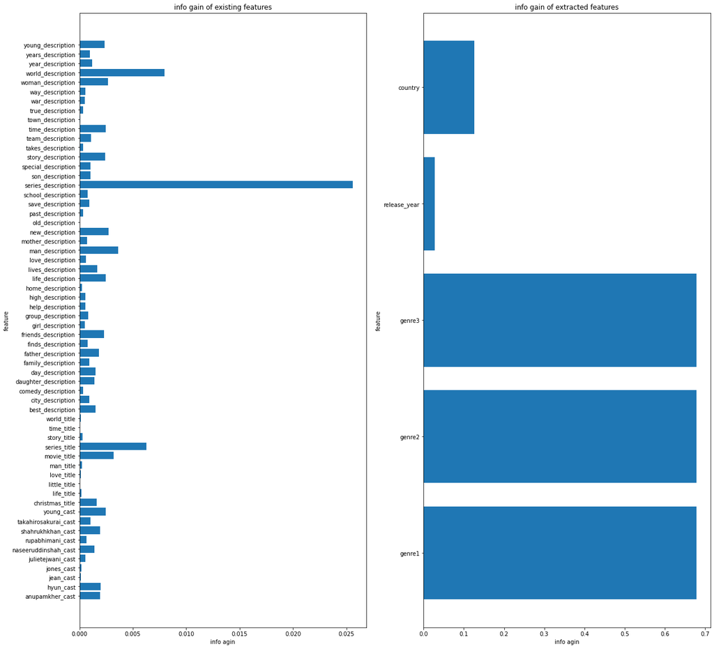

```python
info_gain_new_features = mutual_info_classif(df.drop(columns=['type','genre1', 'genre2', 'genre3', 'release_year', 'country']), df['type'], discrete_features=True)
info_gain_old_features = mutual_info_classif(df[['genre1', 'genre2', 'genre3', 'release_year', 'country']], df['type'], discrete_features=True)

# Figure Size
fig, (ax1, ax2) = plt.subplots(1, 2, figsize =(20,20))

# Horizontal Bar Plot
ax1.barh(df.drop(columns=['type','genre1', 'genre2', 'genre3', 'release_year', 'country']).columns, info_gain_new_features)
ax2.barh(df[['genre1', 'genre2', 'genre3', 'release_year', 'country']].columns, info_gain_old_features)


ax1.set_ylabel('feature')
ax1.set_xlabel('info agin')
ax1.set_title('info gain of existing features')

ax2.set_ylabel('feature')
ax2.set_xlabel('info agin')
ax2.set_title('info gain of extracted features')

plt.show()
```

In this part, we used **mutual_info_classif** function which tells us how much “knowledge” one can gain of a certain variable by knowing the value of another variable.

### Phase 2

#### spliting data

```python
X_train2, X_test2, y_train2, y_test2 = train_test_split(df_ver2.drop(columns=['type']), df_ver2['type'], test_size=0.2, random_state=42)
X_train, X_test, y_train, y_test = train_test_split(df.drop(columns=['type']), df['type'], test_size=0.2, random_state=42)
```

#### _max*depth*

This hyperparameter, determines the maximum depth of the decision tree.

#### _min_samples*split*

This hyperparameter, determines the minimum number of samples required to split an internal node.

We use **GridSearchCV** function to determine value of these hyperparameters in the way that we get best accuracy possible

```python
hyperparams_DT = dict(min_samples_split=range(2,10,1), max_depth=range(5,15,1), min_samples_leaf=range(1,10,1))
clsfr = DecisionTreeClassifier(criterion="entropy", random_state=42)
param_estimator = GridSearchCV(clsfr, hyperparams_DT, cv=5, n_jobs=-1, scoring='accuracy')
param_estimator.fit(X_train, y_train)
print(param_estimator.best_params_)
```

```
{'max_depth': 9, 'min_samples_leaf': 1, 'min_samples_split': 3}
```

```python
clf_model = DecisionTreeClassifier(criterion="entropy", random_state=42, max_depth=9, min_samples_leaf=1, min_samples_split=3)
clf_model.fit(X_train,y_train)

y_predict = clf_model.predict(X_test)
print("accuracy score of DT model is : ", accuracy_score(y_test,y_predict))
```

```
accuracy score of DT model is :  0.9963898916967509
```

#### confusion matrix

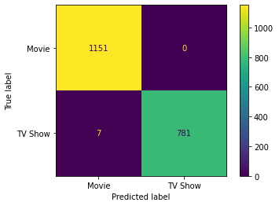

```python
conf_mat = confusion_matrix(y_test, y_predict)
disp = ConfusionMatrixDisplay(confusion_matrix=conf_mat, display_labels=['Movie', 'TV Show'])
disp.plot()
plt.show()
```

As you can see in confusion matrix, we got high accuracy on test data and our model works fine.

#### Evaluation of model with df_ver2 (more features)

```python
clf_model = DecisionTreeClassifier(criterion="entropy", random_state=42, max_depth=9, min_samples_leaf=1, min_samples_split=3)
clf_model.fit(X_train2,y_train2)

y_predict = clf_model.predict(X_test2)
print("accuracy score of model is : ", accuracy_score(y_test2,y_predict))
```

```
accuracy score of model is :  0.9963898916967509
```

We can see that even we extracted more features from text(cast, title, description), there is no difference between accuracy in this case. This could be because of features that have more information gain (like genre features) which are common between two version of datafames.

#### Phase 2 - Q1

```python
X_train2, X_test2, y_train2, y_test2 = train_test_split(df.drop(columns=['type']), df['type'], test_size=0.02, random_state=42)
X_train3, X_test3, y_train3, y_test3 = train_test_split(df.drop(columns=['type']), df['type'], test_size=0.4, random_state=42)


clf_model = DecisionTreeClassifier(criterion="entropy", random_state=42, max_depth=9, min_samples_leaf=1, min_samples_split=3)
clf_model.fit(X_train2,y_train2)

y_predict = clf_model.predict(X_test2)
print("accuracy score of model with proportion of test=2% : ", accuracy_score(y_test2,y_predict))


clf_model.fit(X_train3,y_train3)
y_predict = clf_model.predict(X_test3)
print("accuracy score of model with proportion of test=40% : ", accuracy_score(y_test3,y_predict))
```

```
accuracy score of model with proportion of test=2% :  1.0
accuracy score of model with proportion of test=40% :  0.9958741619391439
```

In our model we used 80% of data for training 20% for testing. With this proportion we can have a good evaluation for our model; Because the portion of train data is big enough, so we don't face with problem of high bias and underfitting. Also poriton of test data is not that much low, so we can find out if our model has overfitting problem.

If we use very big portion of data like 98% for trainnig model, there is high chance that our model become train-data specific; It will act very well on train data with very high accuracy but not on other unseen data. it is called **overfitting**.

In our case, because the portion of test data is very very low and also because of high information gain of some features of data(like genres) this overfitting is not visible

If we use not big enough portion of data for tarining model (like 60%), our model won't be trained good enough and can't even have a good accuracy on train data. In fact, it will be difficault to find appropriate parametes and relationship between features and target in model. this is called **underfitting**

In our case, we can see we lower accuracy in comparison to when we had 80%-20% split on data.

#### Phase 2 - Q2

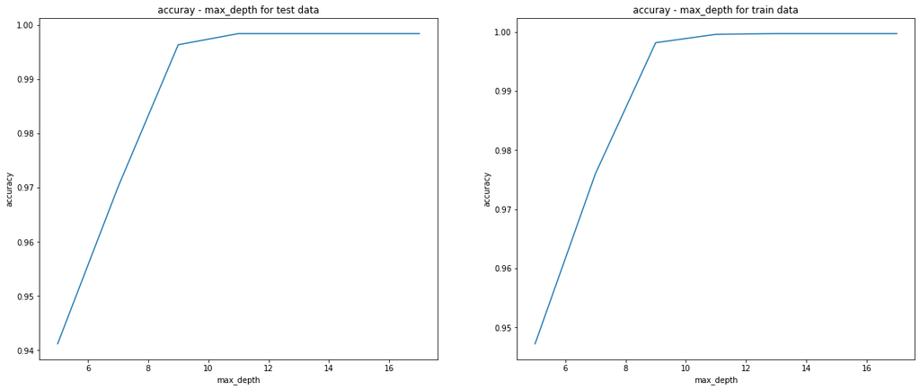

```python
max_depthes = [5, 7, 9, 11, 13, 15, 17]
accuracies_test = [0 for _ in range(7)]
accuracies_train = [0 for _ in range(7)]

for ind in range(7):
    clf_model = DecisionTreeClassifier(criterion="entropy", random_state=42, max_depth=max_depthes[ind], min_samples_leaf=1, min_samples_split=3)
    clf_model.fit(X_train,y_train)
    y_predict = clf_model.predict(X_test)
    accuracies_test[ind] = accuracy_score(y_test,y_predict)
    y_predict = clf_model.predict(X_train)
    accuracies_train[ind] = accuracy_score(y_train,y_predict)


fig, (ax1, ax2) = plt.subplots(1,2,figsize=(20, 8))
ax1.plot(max_depthes, accuracies_test)
ax2.plot(max_depthes, accuracies_train)

ax1.set_ylabel('accuracy')
ax1.set_xlabel('max_depth')
ax1.set_title('accuray - max_depth for test data')

ax2.set_ylabel('accuracy')
ax2.set_xlabel('max_depth')
ax2.set_title('accuray - max_depth for train data')

plt.show()
```

It seems minimum max_depth to get max accuracy possible is around 11 and values after 11, won't effect that much on accuracy

#### cofusion matrix

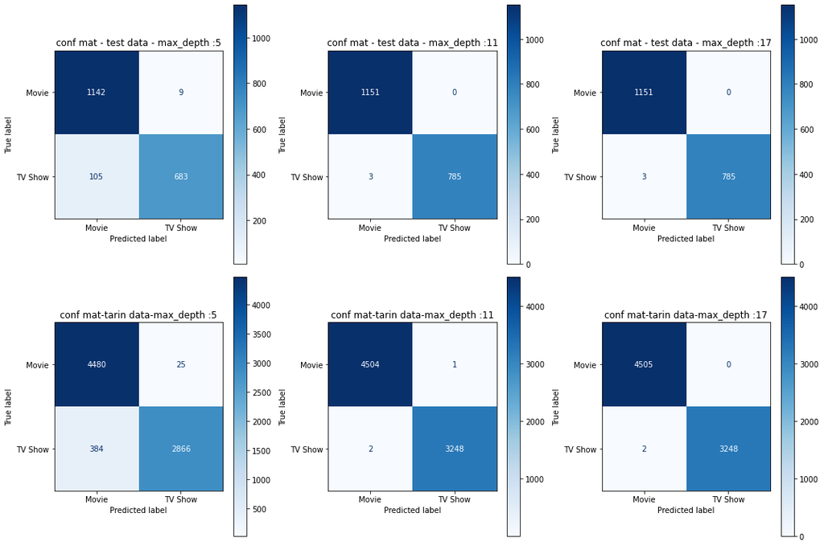

```python
classifiers = [DecisionTreeClassifier(criterion="entropy", random_state=42, max_depth=depth, min_samples_leaf=1, min_samples_split=3)
                for depth in [5, 11, 17]] * 2
for cls in classifiers:
    cls.fit(X_train, y_train)

fig, axes = plt.subplots(nrows=2, ncols=3, figsize=(15,10))

clfs_axs = list(zip(classifiers, axes.flatten()))
for ind, (cls, ax) in enumerate(clfs_axs):
    if ind < 3:
        plot_confusion_matrix(cls,
                            X_test,
                            y_test,
                            ax=ax,
                            cmap='Blues',
                            display_labels=['Movie', 'TV Show'])
        ax.title.set_text('conf mat - test data - max_depth :' + str(5+ind*6))
    else:
        plot_confusion_matrix(cls,
                            X_train,
                            y_train,
                            ax=ax,
                            cmap='Blues',
                            display_labels=['Movie', 'TV Show'])
        ax.title.set_text('conf mat-tarin data-max_depth :' + str(5+(ind-3)*6))

plt.tight_layout()
plt.show()
```

Above, confusion matrixes are plotted the result of prediction of decision trees with different max_depth for test and train data

### Phase 3

#### Two special hyperparamters of RandomForestClassifer:

1- n_estimators : determines the number of trees in the forest.

2- max_samples : determines the number of samples to peak from X(train data) to train each base estimator(tree).

In this phase, we first try to get best hyperparameters for classifier via **GridSearchCV** function. Then we compare accuracy with and without determining these hyperparameters.

```python
# **** takes too much time to execute (around 7 mins)
DT_params = dict(max_samples=[0.8,0.9,0.95], max_depth=range(41, 51, 2), min_samples_split=range(3,13, 2), n_estimators=range(10,110,10))
clsfr = RandomForestClassifier(criterion="entropy", random_state=42, n_jobs=-1)
param_estimator = GridSearchCV(clsfr, DT_params, cv=5, n_jobs=-1)
param_estimator.fit(X_train, y_train)
print(param_estimator.best_params_)
```

```
{'max_depth': 41, 'max_samples': 0.95, 'min_samples_split': 3, 'n_estimators': 100}
```

```python
clf_model = RandomForestClassifier(criterion="entropy", max_samples=0.95, n_estimators=100, random_state=42, max_depth=41, min_samples_leaf= 1, min_samples_split=3, n_jobs=-1)
clf_model.fit(X_train,y_train)

clf_model2 = RandomForestClassifier(criterion="entropy", bootstrap=False, n_estimators=100, random_state=42, max_depth=41, min_samples_leaf= 1, min_samples_split=3, n_jobs=-1)
clf_model2.fit(X_train,y_train)

accuracies = [0, 0]

y_predict = clf_model.predict(X_test)
accuracies[0] = accuracy_score(y_test,y_predict)
print("accuracy score of Random forst model with hyperparamers :", accuracies[0])

y_predict2 = clf_model2.predict(X_test)
accuracies[1] = accuracy_score(y_test,y_predict2)
print("accuracy score of Random forst model without hyperparamers :", accuracy_score(y_test,y_predict2))
```

```
accuracy score of Random forst model with hyperparamers : 0.9938112429087158
accuracy score of Random forst model without hyperparamers : 0.9943269726663229
```

#### Plotting

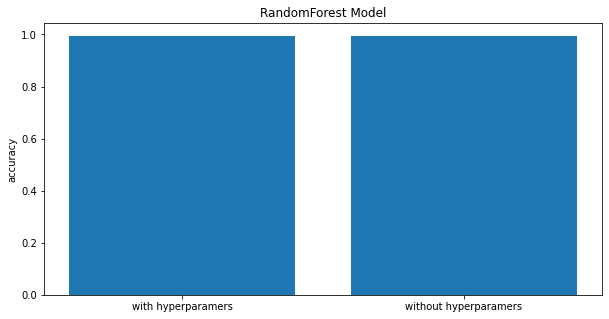

```python
plt.figure(figsize=(10,5))
plt.bar(['with hyperparamers', 'without hyperparamers'], accuracies)
plt.ylabel('accuracy')
plt.title('RandomForest Model')

plt.show()
```

It seems, in our case, there aren't almost any difference if we use these two special parameters or not.

#### Comparison of DT and RF

```python
clf_RF = RandomForestClassifier(criterion="entropy", bootstrap=False, n_estimators=100, random_state=42, max_depth=41, min_samples_leaf= 1, min_samples_split=3, n_jobs=-1)
clf_RF.fit(X_train,y_train)

clf_DT = DecisionTreeClassifier(criterion="entropy", random_state=42, max_depth=11, min_samples_leaf=1, min_samples_split=3)
clf_DT.fit(X_train,y_train)

accuracies_RF = [0, 0]
accuracies_DT = [0, 0]

y_predict = clf_RF.predict(X_test)
accuracies_RF[0] = accuracy_score(y_test,y_predict)
print("accuracy score RF-test : ", accuracies_RF[0])

y_predict = clf_RF.predict(X_train)
accuracies_RF[1] = accuracy_score(y_train,y_predict)
print("accuracy score RF-train : ", accuracies_RF[1])

y_predict = clf_DT.predict(X_test)
accuracies_DT[0] = accuracy_score(y_test,y_predict)
print("accuracy score DT-test : ", accuracies_DT[0])

y_predict = clf_DT.predict(X_train)
accuracies_DT[1] = accuracy_score(y_train,y_predict)
print("accuracy score DT-train : ", accuracies_DT[1])
```

```
accuracy score RF-test :  0.9943269726663229
accuracy score RF-train :  1.0
accuracy score DT-test :  0.998452810727179
accuracy score DT-train :  0.9996131528046421
```

Generally we expect RF to be a model with low variance in comparison to DT model. Because in RF we use more than one decision tree, and with different features and samples to decide about target. So it is more generalized and not dependent on just one dataset. Also, RF often have equal or less bias than DT model. Because RF does not peak low portion of main train data for each tree that each tree would become a model with high bias.

But in the above result we can observe that variance in RF is little bit more than varicance in DT. Because accuracy for train data is 100%(which is kind of train-data specific) unlike DT. And also the accuracy for test data is lower than accuracy in DT